# Analyses: Classification Performance

Chris Bentz

06.03.2025

# Description

This file enables post-hoc analyses of the performance values (F1-scores, accuracies, p-values) of the KNN and MLP classifications. It provides density distributions for these performance metrics.

# Preliminaries: Performance Metrics

```r
knitr::include_graphics("~/Github/PaleoSigns/figures_external/confusionMatrix.png")
```

[output not shown]

The accuracy is then calculated as

$$\begin{equation}
accuracy = \frac{A + D}{A + D + B + C}.
\end{equation}$$

$$\begin{equation}
H_0: p = p_0
\end{equation}$$

and

$$\begin{equation}
H_1: p > p_0
\end{equation}$$

$$\begin{equation}
B^* = \frac{B - E_{p0}(B)}{\sqrt{\sigma^2_{p0}(B)}}.
\end{equation}$$

Under $H_0$ the standardized $B^*$ is assumed to follow a normal binomial distribution $\mathcal{N}(0,1)$. We can then identify a z-score given an $\alpha$-level of our choice, which the actual $B^*$ we calculate from the data would have to surpass to reject $H_0$. With the common $\alpha = 0.05$, we have $z_{\alpha} = 1.645$.

As a worked example, assume that in one of the runs of the MLP architecture classifying Aurignacian and Uruk V sequences the success rate is 75. In this case, we have:

$$\begin{equation}
B^* = \frac{B - E_{p0}(B)}{\sqrt{\sigma^2_{p0}(B)}} = \frac{75 -
69}{\sqrt{21.86139}} \sim 1.28
\end{equation}$$

Hence, $B^* < z_{\alpha}$, and we would accept $H_0$, meaning that the MLP classification is not significantly better than the “no information rate” baseline. The model has not learned (from the training set) to distinguish between these sequences better than the baseline (i.e. if it just chose the most frequent label).

Apart from the accuracy, we also report the $F_\beta$-score, which can be generally defined as:

$$\begin{equation}
F_\beta = \frac{(1 + \beta^2) \times precision \times recall}{(\beta^2
\times precision) + recall}.
\end{equation}$$

In the confusionMatrix() function the special case $\beta^2 = 1$ is implemented, thus giving an $F_1$-score as

$$\begin{equation}
F_1 = \frac{2 \times precision \times recall}{precision + recall}.
\end{equation}$$

Furthermore, precision is defined as

$$\begin{equation}
precision = \frac{A}{A + B},
\end{equation}$$

and recall as

$$\begin{equation}
recall = \frac{A}{A + C}.
\end{equation}$$

In other words, precision measures how often the positive class (also called “Event” in the documentation) is correctly predicted (true positives) in relation to the overall number of times this class is predicted by the model (true positives + false positives). In other words, how often is the classifier correct when it predicts the positive class? The recall, on the other hand, measures how often the positive class is correctly predicted (true positives) in relation to the overall number of “actually observed” instances of this class in the test set (true positives + false negatives). In other words, how often does the model “find” or “recall” the correct class?

The F-score is then a harmonized mean over prediction and recall. The rational behind this is to make the results more robust in the face of imbalances in terms of the distribution of class labels in the test set.

# Session Info

Give the session info (reduced).

```
## [1] "R version 4.3.3 (2024-02-29)"
```

```
## [1] "x86_64-pc-linux-gnu"
```

# Load libraries

If the libraries are not installed yet, you need to install them using, for example, the command: install.packages(“ggplot2”).

```r
library(ggplot2)
library(ggExtra)
library(gridExtra)
library(ggpubr)
library(ggridges)
library(tidyverse)
library(data.table)
library(caret)
```

Give the package versions.

```
##      caret    lattice data.table  lubridate    forcats    stringr      dplyr
##    "7.0-1"   "0.22-5"   "1.17.0"    "1.9.4"    "1.0.0"    "1.5.1"    "1.1.4"
##      purrr      readr      tidyr     tibble  tidyverse   ggridges     ggpubr
##    "1.0.4"    "2.1.5"    "1.3.1"    "3.2.1"    "2.0.0"    "0.5.6"    "0.6.0"
##  gridExtra    ggExtra    ggplot2
##      "2.3"   "0.10.1"    "3.5.1"
```

# Multi-layer perceptron (MLP)

## Load Data

```r
# list files in the performance folders
files.mlp.performance <-
  list.files(path = "~/Github/PaleoSigns/results/classifier/MLP/performance", full.names = T)
```

## Preprocessing

P-value adjustment for multiple comparisons: In case of multiple testing, we need account for the fact that the likelihood of finding a significant result by chance increases with the number of statistical tests executed. One of the most conservative methods to account for this is the so-called Bonferroni correction, i.e. multiplying the p-values with the number of tests. This method is appropriate when tests are independent of one another (cf. MacDonald 2014, p. 254-260). In our case, each test for each sequence can be seen as an independent trial. We therefore apply this conservative Bonferroni method (see also the descriptions in the vignette invoked by the command “?p.adjust()”).

```r
# initialize empty data frame
performance.mlp.combined <- data.frame(hidden.structure = character(0),
                                   hidden.size = numeric(0),
                                   hidden.depth = numeric(0),
                                   err.fct = character(0),
                                   act.fct.name = character(0),
                                   algorithm = character(0),
                                   baseline = numeric(0),
                                   accuracy = numeric(0),
                                   accuracy.pvalue = numeric(0),
                                   precision = numeric(0),
                                   recall = numeric(0),
                                   f1 = numeric(0),
                                   accuracy.pvalue.corrected = numeric(0),
                                   comparison = character(0))

# loop through all files and combine them
for (file in files.mlp.performance){
  performance.data <- read.csv(file)
  # apply bonferroni correction
  performance.data$accuracy.pvalue.corrected <- p.adjust(performance.data$accuracy.pvalue,
                               method = "bonferroni",
                               n = nrow(performance.data))
  # get the subcorpora involved in the binary classification
  filename.parts <- unlist(strsplit(basename(file), "\\_|\\."))
  subcorpus1 <- filename.parts[3]
  subcorpus2 <- filename.parts[4]
  performance.data$comparison <- rep(paste(subcorpus1, "vs.", subcorpus2),
                                     nrow(performance.data))
  # add to data frame
  performance.mlp.combined <- rbind(performance.mlp.combined, performance.data)
}
head(performance.mlp.combined)
```

```
##   hidden.structure hidden.size hidden.depth err.fct act.fct.name algorithm
## 1            3,5,4          12            3     sse         tanh    rprop+
## 2            3,3,2           8            3     sse         tanh    rprop+
## 3            5,2,4          11            3     sse         tanh    rprop+
## 4            3,1,1           5            3     sse         tanh    rprop+
## 5                3           3            1     sse         tanh    rprop+
## 6            5,3,1           9            3     sse         tanh    rprop+
##   baseline accuracy accuracy.pvalue precision recall   f1 test.n
## 1     0.79     0.92    4.223617e-10      0.80   0.80 0.80    340
## 2     0.79     0.93    4.356666e-12      0.82   0.84 0.83    340
## 3     0.79     0.93    1.249968e-12      0.83   0.84 0.84    340
## 4     0.79     0.93    1.453743e-11      0.77   0.91 0.84    340
## 5     0.79     0.92    4.223617e-10      0.82   0.77 0.79    340
## 6     0.79     0.94    3.427401e-13      0.82   0.87 0.85    340
##   accuracy.pvalue.corrected                           comparison
## 1              2.660879e-08 Aurignacian vs. Cuneiform (Uruk III)
## 2              2.744699e-10 Aurignacian vs. Cuneiform (Uruk III)
## 3              7.874801e-11 Aurignacian vs. Cuneiform (Uruk III)
## 4              9.158579e-10 Aurignacian vs. Cuneiform (Uruk III)
## 5              2.660879e-08 Aurignacian vs. Cuneiform (Uruk III)
## 6              2.159262e-11 Aurignacian vs. Cuneiform (Uruk III)
```

## Density Plots

### F1 Distributions

Distributions of F1-scores by comparison.

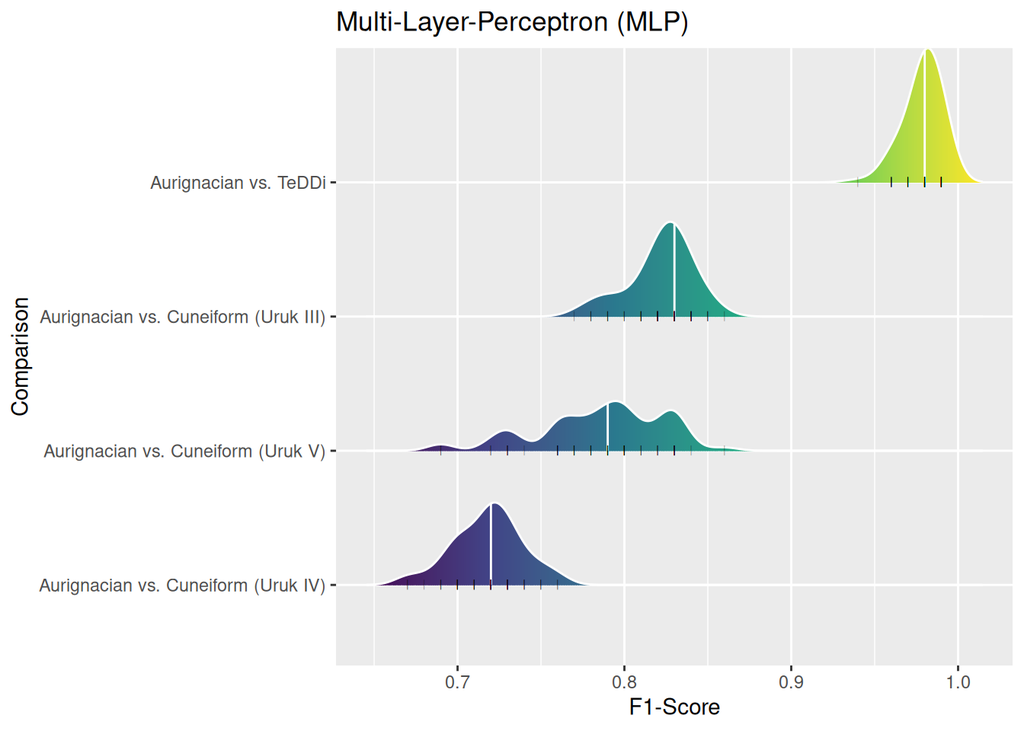

```r
f1.mlp.plot <- ggplot(performance.mlp.combined, aes(x = f1,
                                            y = fct_reorder(comparison, f1),
                                            fill = after_stat(x))) +
  geom_density_ridges_gradient(scale = 1, color = "white",
                               quantile_lines = T, quantiles = 2) +
  scale_fill_viridis_c(name = "F1-Score", option = "D") +
  geom_point(shape = 124, alpha = 0.4, size = 1.5) +
  xlab("F1-Score") +
  ylab("Comparison") +
  theme(legend.position = "none") +
  ggtitle("Multi-Layer-Perceptron (MLP)")
f1.mlp.plot
```

## Accuracy Distributions

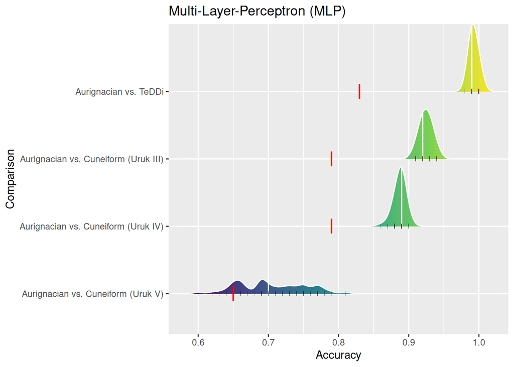

```r
accuracy.mlp.plot <- ggplot(performance.mlp.combined, aes(x = accuracy,
                                            y = fct_reorder(comparison, accuracy),
                                            fill = after_stat(x))) +
  geom_density_ridges_gradient(scale = 1, color = "white",
                               quantile_lines = T, quantiles = 2) +
  scale_fill_viridis_c(name = "Accuracy", option = "D") +
  geom_point(shape = 124, alpha = 0.4, size = 1.5) +
  geom_point(shape = 124, size = 5, aes(x = baseline, y = comparison), color = "red") +
  xlab("Accuracy") +
  ylab("Comparison") +
  theme(legend.position = "none") +
  ggtitle("Multi-Layer-Perceptron (MLP)")
accuracy.mlp.plot
```

## P-value Distributions

Distributions of p-values by comparison.

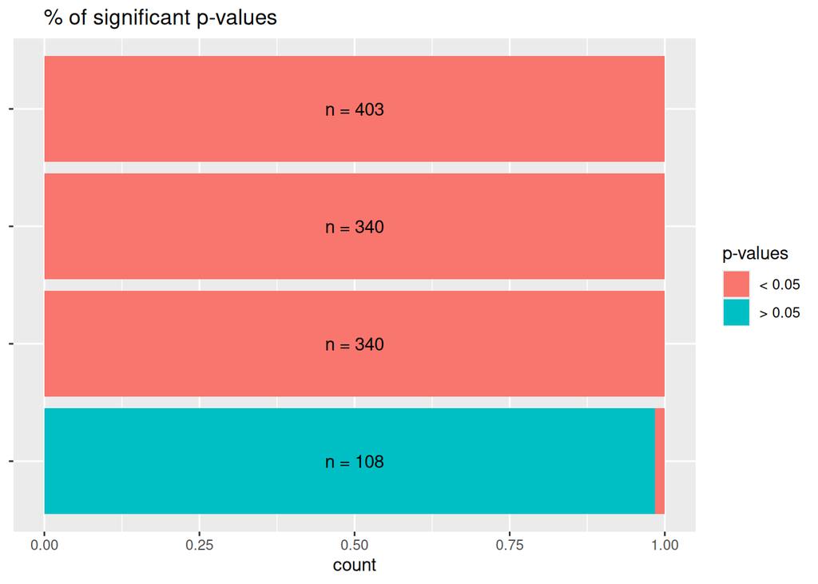

```r
# get split between cases where p < 0.05 and p > 0.05
performance.mlp.combined$accuracy.pvalue.corrected <-
  ifelse(performance.mlp.combined$accuracy.pvalue.corrected < 0.05, "< 0.05", "> 0.05")

# create plot
pvalue.mlp.plot <- ggplot(performance.mlp.combined, aes(y = fct_reorder(comparison, accuracy),
                                                    fill = as.factor(accuracy.pvalue.corrected))) +
  geom_bar(stat = "count", position = "fill") +
  geom_text(x = 0.5, label = paste("n = ", performance.mlp.combined$test.n, sep = ""),
            check_overlap = T) +
  theme(axis.title.y = element_blank(),
        axis.text.y = element_blank()) +
  scale_fill_discrete(name = "p-values") +
  ggtitle("     % of significant p-values")
pvalue.mlp.plot
```

# K-Nearest-Neighbors (KNN)

## Load Data

```r
# list files in the performance folders
files.knn.performance <- list.files(path = "~/Github/PaleoSigns/results/classifier/KNN/performance", full.names = T)
```

## Preprocessing

```r
# initialize empty data frame
performance.knn.combined <- data.frame(k = numeric(0),
                                   baseline = numeric(0),
                                   accuracy = numeric(0),
                                   accuracy.pvalue = numeric(0),
                                   precision = numeric(0),
                                   recall = numeric(0),
                                   f1 = numeric(0),
                                   accuracy.pvalue.corrected = numeric(0),
                                   comparison = character(0))

# loop through all files and combine them
for (file in files.knn.performance){
  performance.data <- read.csv(file)
  # apply bonferroni correction
  performance.data$accuracy.pvalue.corrected <- p.adjust(performance.data$accuracy.pvalue,
                               method = "bonferroni",
                               n = nrow(performance.data))
  # get the subcorpora involved in the binary classification
  filename.parts <- unlist(strsplit(basename(file), "\\_|\\."))
  subcorpus1 <- filename.parts[3]
  subcorpus2 <- filename.parts[4]
  performance.data$comparison <- rep(paste(subcorpus1, "vs.", subcorpus2),
                                     nrow(performance.data))
  # add to data frame
  performance.knn.combined <- rbind(performance.knn.combined, performance.data)
}
head(performance.knn.combined)
```

```
##   k baseline accuracy accuracy.pvalue precision recall   f1 test.n
## 1 1     0.79     0.91    8.727430e-09      0.79   0.76 0.77    340
## 2 2     0.79     0.91    1.201767e-09      0.80   0.79 0.79    340
## 3 3     0.79     0.93    1.453743e-11      0.83   0.81 0.82    340
## 4 4     0.79     0.93    1.249968e-12      0.83   0.84 0.84    340
## 5 5     0.79     0.93    4.356666e-12      0.83   0.83 0.83    340
## 6 6     0.79     0.93    1.249968e-12      0.84   0.83 0.83    340
##   accuracy.pvalue.corrected                           comparison
## 1              8.727430e-08 Aurignacian vs. Cuneiform (Uruk III)
## 2              1.201767e-08 Aurignacian vs. Cuneiform (Uruk III)
## 3              1.453743e-10 Aurignacian vs. Cuneiform (Uruk III)
## 4              1.249968e-11 Aurignacian vs. Cuneiform (Uruk III)
## 5              4.356666e-11 Aurignacian vs. Cuneiform (Uruk III)
## 6              1.249968e-11 Aurignacian vs. Cuneiform (Uruk III)
```

## Density Plots

### F1 Distributions

Distributions of F1-scores by comparison.

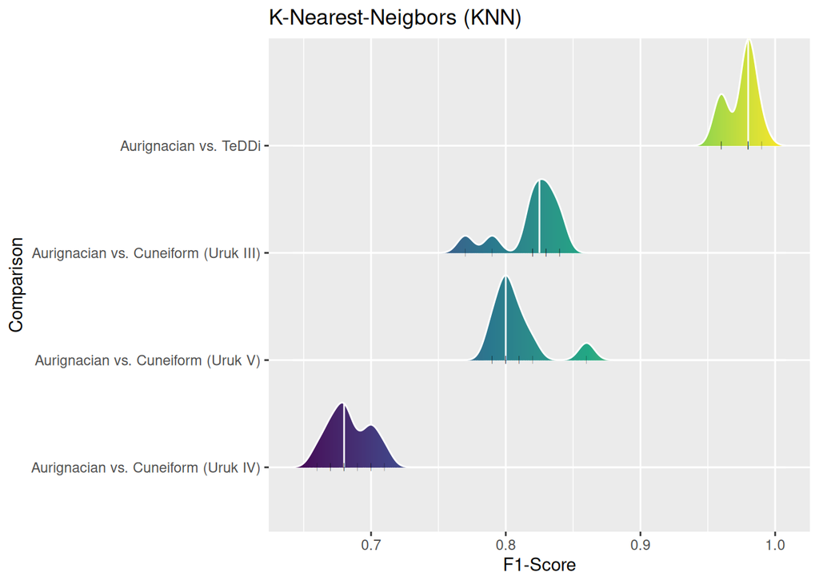

```r
f1.knn.plot <- ggplot(performance.knn.combined, aes(x = f1,
                                            y = fct_reorder(comparison, f1),
                                            fill = after_stat(x))) +
  geom_density_ridges_gradient(scale = 1, color = "white",
                               quantile_lines = T, quantiles = 2) +
  scale_fill_viridis_c(name = "F1-Score", option = "D") +
  geom_point(shape = 124, alpha = 0.4, size = 1.5) +
  xlab("F1-Score") +
  ylab("Comparison") +
  theme(legend.position = "none")+
  ggtitle("K-Nearest-Neigbors (KNN)")
f1.knn.plot
```

## Accuracy Distributions

Distributions of accuracies by comparison.

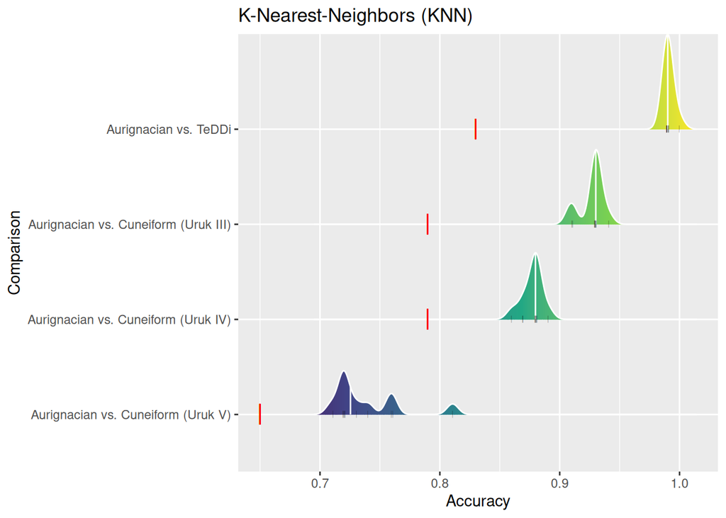

```r
accuracy.knn.plot <- ggplot(performance.knn.combined, aes(x = jitter(accuracy, amount = 0.001),
                                            y = fct_reorder(comparison, accuracy),
                                            fill = after_stat(x))) +
  geom_density_ridges_gradient(scale = 1, color = "white",
                               quantile_lines = T, quantiles = 2) +
  scale_fill_viridis_c(name = "Accuracy", option = "D") +
  geom_point(shape = 124, alpha = 0.4, size = 1.5) +
  geom_point(shape = 124, size = 5, aes(x = baseline, y = comparison), color = "red") +
  xlab("Accuracy") +
  ylab("Comparison") +
  theme(legend.position = "none") +
  ggtitle("K-Nearest-Neighbors (KNN)")
accuracy.knn.plot
```

## P-value Distributions

Distributions of p-values by comparison.

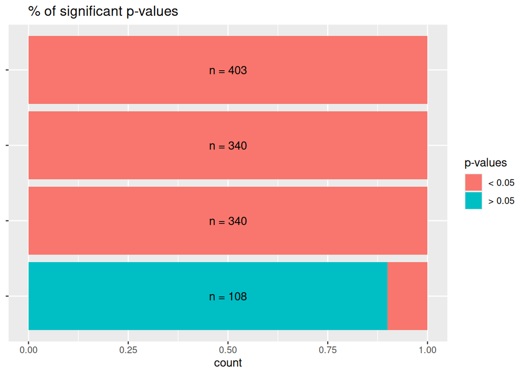

```r
# get split between cases where p < 0.05 and p > 0.05
performance.knn.combined$accuracy.pvalue.corrected <-
  ifelse(performance.knn.combined$accuracy.pvalue.corrected < 0.05, "< 0.05", "> 0.05")

# create plot
pvalue.knn.plot <- ggplot(performance.knn.combined, aes(y = fct_reorder(comparison, accuracy),
                                                    fill = as.factor(accuracy.pvalue.corrected))) +
  geom_bar(stat = "count", position = "fill") +
  geom_text(x = 0.5, label = paste("n = ", performance.knn.combined$test.n, sep = ""),
            check_overlap = T) +
  theme(axis.title.y = element_blank(),
        axis.text.y = element_blank()) +
  scale_fill_discrete(name = "p-values") +
  ggtitle("     % of significant p-values")
pvalue.knn.plot
```

## Combine Plots

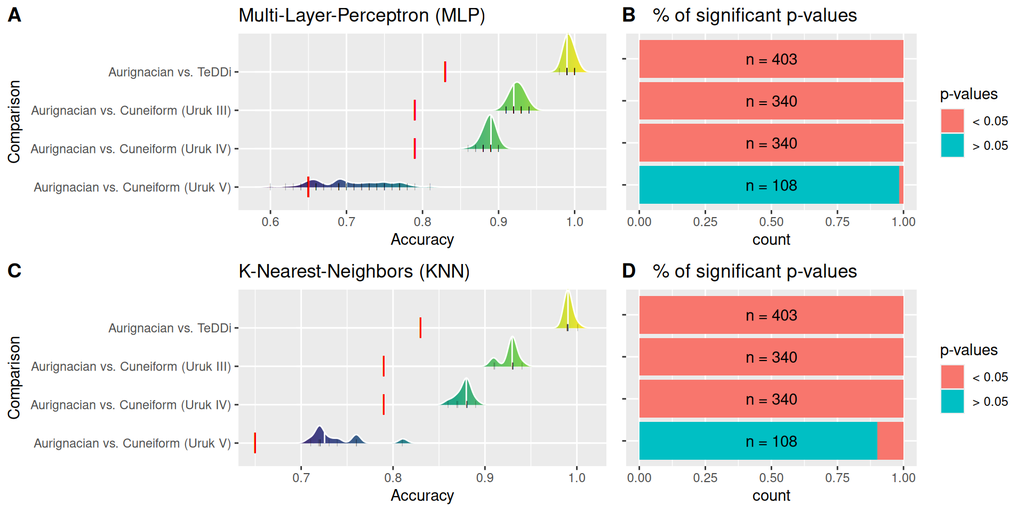

```r
combined.plot <- ggarrange(accuracy.mlp.plot, pvalue.mlp.plot,
                           accuracy.knn.plot, pvalue.knn.plot,
                           ncol = 2, nrow = 2,
                           widths = c(1.5, 1), labels = "AUTO")
combined.plot
```

Safe to file.

```r
ggsave("~/Github/PaleoSigns/figures/performancePlot.pdf",
       combined.plot, dpi = 300, width = 10, height = 5, device = cairo_pdf)
```

# Package References

```
## Wickham H (2016). _ggplot2: Elegant Graphics for Data Analysis_.
## Springer-Verlag New York. ISBN 978-3-319-24277-4,
## <https://ggplot2.tidyverse.org>.
```

```
## Attali D, Baker C (2023). _ggExtra: Add Marginal Histograms to
## 'ggplot2', and More 'ggplot2' Enhancements_. R package version 0.10.1,
## <https://CRAN.R-project.org/package=ggExtra>.
```

```
## Auguie B (2017). _gridExtra: Miscellaneous Functions for "Grid"
## Graphics_. R package version 2.3,
## <https://CRAN.R-project.org/package=gridExtra>.
```

```
## Kassambara A (2023). _ggpubr: 'ggplot2' Based Publication Ready Plots_.
## R package version 0.6.0, <https://CRAN.R-project.org/package=ggpubr>.
```

```
## Wilke C (2024). _ggridges: Ridgeline Plots in 'ggplot2'_. R package
## version 0.5.6, <https://CRAN.R-project.org/package=ggridges>.
```

```
## Wickham H, Averick M, Bryan J, Chang W, McGowan LD, François R,
## Grolemund G, Hayes A, Henry L, Hester J, Kuhn M, Pedersen TL, Miller E,
## Bache SM, Müller K, Ooms J, Robinson D, Seidel DP, Spinu V, Takahashi
## K, Vaughan D, Wilke C, Woo K, Yutani H (2019). "Welcome to the
## tidyverse." _Journal of Open Source Software_, *4*(43), 1686.
## doi:10.21105/joss.01686 <https://doi.org/10.21105/joss.01686>.
```

```
## Barrett T, Dowle M, Srinivasan A, Gorecki J, Chirico M, Hocking T,
## Schwendinger B, Krylov I (2025). _data.table: Extension of
## `data.frame`_. R package version 1.17.0,
## <https://CRAN.R-project.org/package=data.table>.
```

```
## Kuhn, Max (2008). "Building Predictive Models in R Using the caret
## Package." _Journal of Statistical Software_, *28*(5), 1–26.
## doi:10.18637/jss.v028.i05 <https://doi.org/10.18637/jss.v028.i05>,
## <https://www.jstatsoft.org/index.php/jss/article/view/v028i05>.
```

# Literature References

Hollander, M., Wolfe, D. A., & Chicken, E. (2014). Nonparametric statistical methods. John Wiley & Sons.

Kuhn, M. (2008). Building predictive models in R using the caret package. Journal of Statistical Software, 28, 1-26.

McDonald, J.H. (2014). Handbook of Biological Statistics (3rd ed.). Sparky House Publishing, Baltimore, Maryland. online at http://www.biostathandbook.com